# A summary of the tweets generated at the 2016 Ecological Society of America meeting (#ESA2016)

E.J. Rollinson

## About this document

This document was produced by [Emily J. Rollinson](http://rollinsonecology.com) (ejrollinson on Twitter).

The code generating this document was originally developed by [Francois Michonneau](https://github.com/fmichonneau) (fmic_ on Twitter) for the 2015 Evolution meeting and can be found [here](https://github.com/fmichonneau/evol2015-tweets).

It has since been [adapted](https://github.com/jlehtoma/iccb2015-tweets/blob/gh-pages/index.Rmd) for ICCB-ECCB 2015 by Joona Lehtomaki (jlehtoma on Twitter).

Thanks also to Emily Sessa (ebsessa on Twitter) for reproducing this code for the 2015 Botany meeting, bringing it to my attention.

I originally adapted this code for the 2015 Ecological Society of America Meeting (#ESA100) in Baltimore, MD, and have reproduced it here for the 2016 Ecological Society of America Meeting (#ESA2016) in Fort Lauderdale, FL.

Tweets using the hashtag #ESA2016 were aggregated from Twitter using the R package [twitteR](https://cran.r-project.org/web/packages/twitteR/index.html) and the Twitter API. The aggregated tweets are [available on Figshare](https://figshare.com/authors/Emily_Rollinson/781925).

This document was generated using RMarkdown, and the source is [available on GitHub](https://github.com/erollinson/erollinson.github.io).

This document (and associated code) is released under a CC0 licence.

## Basic summary

Of the most recent 12k tweets tagged #ESA2016 (As of 4:30 PM 8/13/2016):

| Description | n |
| --- | --- |
| Total of original tweets (no retweets): | 6114 |
| Number of users who tweeted: | 2216 |

## The 5 most favorited tweets

> Beautiful poster design from @polesasunder (and good ecology, too) #ESA2016 https://t.co/C3tsr1wY94

> — carlyziter | [2016-08-08](https://twitter.com/carlyziter/status/762771345511972864) | 26 retweets, 85 favorites.

> The best thing about #ESA2016 is the annual reminder that ecologists are Good People and genuinely fun to interact with (except reviewer 2).

> — tpoi | [2016-08-10](https://twitter.com/tpoi/status/763497383015571456) | 25 retweets, 81 favorites.

> If Charles Darwin can feel “very poorly and very stupid” and that “one lives only to make blunders,” then we can, too. - @labroides #ESA2016

> — JacquelynGill | [2016-08-11](https://twitter.com/JacquelynGill/status/763738245876346880) | 49 retweets, 67 favorites.

> My #ESA2016 Ignite talk in a nutshell. https://t.co/EU2ihZDOMy

> — tpoi | [2016-08-09](https://twitter.com/tpoi/status/762987458090954752) | 40 retweets, 59 favorites.

> Question in session: how do you know that your undergrads are just not making data up? I say WTF? Maybe by building mutual trust? #ESA2016

> — hormiga | [2016-08-10](https://twitter.com/hormiga/status/763384137487179776) | 14 retweets, 58 favorites.

## The 5 most retweeted tweets

> If Charles Darwin can feel “very poorly and very stupid” and that “one lives only to make blunders,” then we can, too. - @labroides #ESA2016

> — JacquelynGill | [2016-08-11](https://twitter.com/JacquelynGill/status/763738245876346880) | 49 retweets, 67 favorites.

> We need to stop putting diversity in a box. #ESA2016 https://t.co/G4ww2XJDwq

> — hormiga | [2016-08-10](https://twitter.com/hormiga/status/763465600815337472) | 48 retweets, 44 favorites.

> My #ESA2016 Ignite talk in a nutshell. https://t.co/EU2ihZDOMy

> — tpoi | [2016-08-09](https://twitter.com/tpoi/status/762987458090954752) | 40 retweets, 59 favorites.

> In #Florida #climatechange is not a theory  its happening right here, right now! https://t.co/5JUw2vU3do #ESA2016 https://t.co/i2CtVEsXK3

> — Nature_Florida | [2016-08-07](https://twitter.com/Nature_Florida/status/762404523579244544) | 39 retweets, 28 favorites.

> Collecting for natural history museums is “a dying art worth saving and teaching”. #herbariums #ESA2016

> — emgbotany | [2016-08-10](https://twitter.com/emgbotany/status/763365728514895872) | 32 retweets, 51 favorites.

## Top tweeters

All generated tweets (including retweets)

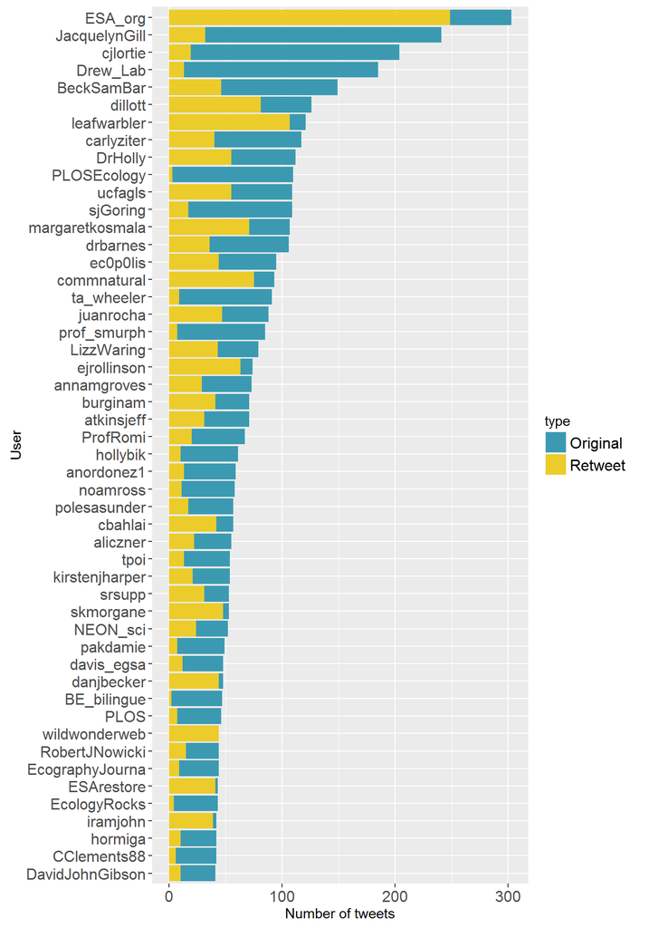

Only for original tweets (retweets excluded)

[figure not shown]

## Most favorited/retweeted users

The figures below only include users who tweeted 5+ times, and don’t include retweets.

### Number of favorites received by users

[figure not shown]

### Number of retweets received by users

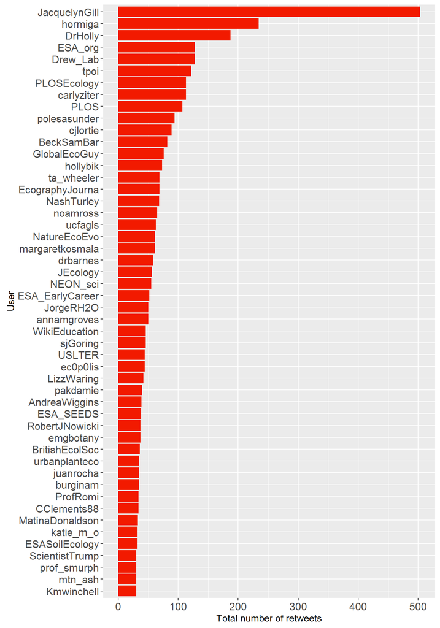

### Mean numbers of favorites received

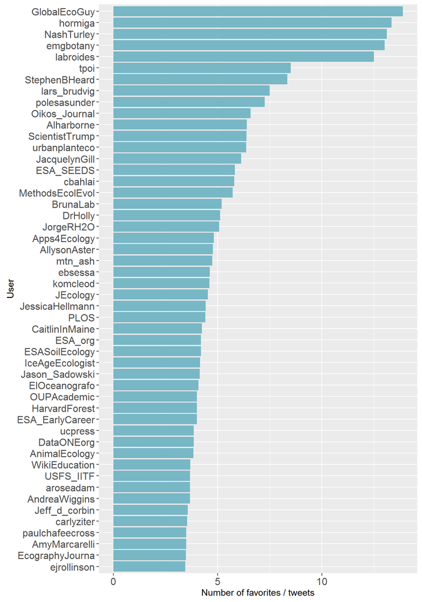

### Mean numbers of retweets received

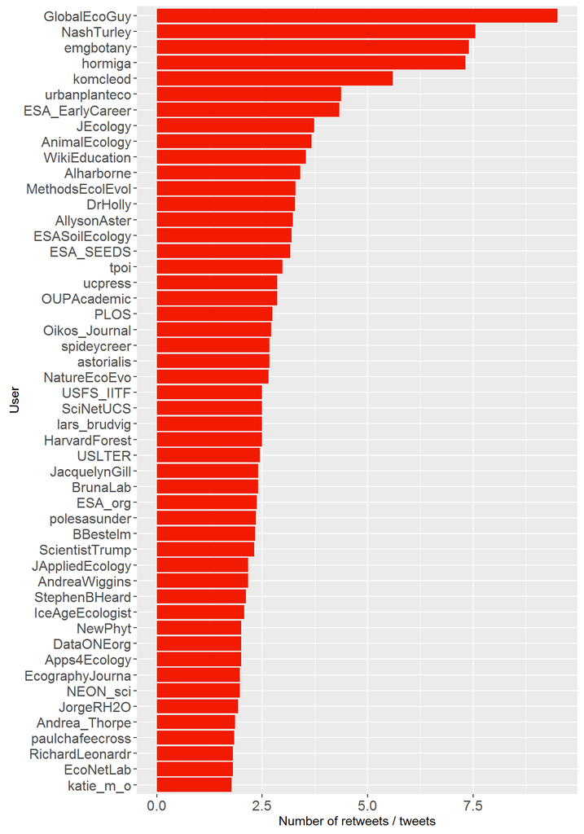

## Word cloud

The top 100 words among the original tweets.

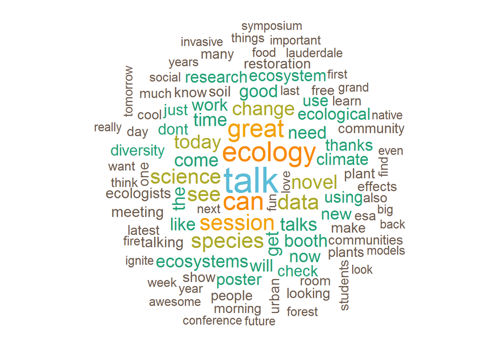

To the extent possible under law, [Emily J. Rollinson](https://github.com/erollinson/erollinson.github.io) has waived all copyright and related or neighboring rights to Summary of tweets at the 2016 Ecological Society of America conference. This work is published from: United States.